# 13. 다양한 그래프

### 13.19 배경이 깨끗한 지도 만들기

지도에서 배경 요소들을 제거한다.

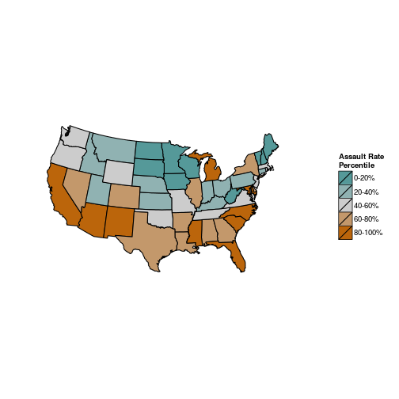

```r
# 많은 배경 요소들을 제거한 테마를 생성한다.
theme_clean <- function(base_size = 12) {
require(grid) # unit() 함수를 위해 필요
  theme_grey(base_size) %+replace%
  theme(
    axis.title        = element_blank(),
    axis.text         = element_blank(),
    panel.background  = element_blank(),
    panel.grid        = element_blank(),
    axis.ticks.length = unit(0, "cm"),
    axis.ticks.margin = unit(0, "cm"),
    panel.margin      = unit(0, "lines"),
    plot.margin       = unit(c(0, 0, 0, 0), "lines"),
    complete = TRUE
  )
}

# 지도에 테마를 추가한다.
ggplot(crimes, aes(map_id = state, fill=Assault_q)) +
    geom_map(map = states_map, colour="black") +
    scale_fill_manual(values=pal) +
    expand_limits(x = states_map$long, y = states_map$lat) +
    coord_map("polyconic") +
    labs(fill="Assault Rate\nPercentile") +
    theme_clean()
```

일부 지도에서는 위도와 경도 같은 맥락 정보를 표기해주는 것이 중요할 때도 있지만, 때로는 오히려 전달하고자 하는 정보를 방해할 때도 있으므로 적절히 적용해야 한다.

### 13.20 Shapefile로부터 지도 만들기

Esri shapefile을 가지고 지리적 지도를 만들기 위해  
maptools 패키지의 readShapePoly()를 사용해 shapefile을 로딩한 다음  
fortify()를 써서 데이터 프레임으로 변환하고 그래프로 그린다.

- shapefile들은 www.gadm.org에서 다운로드할 수 있다.
- 사이트에 들어가보면 다운로드가 안되고, shapefile이 없으면 아래 코드는 실행되지 않음.

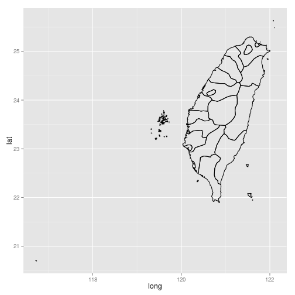

```r
#install.packages("maptools")
library(maptools)

### shapefile을 로딩한 다음 데이터 프레임으로 변환
taiwan_shp <- readShapePoly("TWN_adm/TWN_adm2.shp")
taiwan_map <- fortify(taiwan_shp)
ggplot(taiwan_map, aes(x = long, y = lat, group=group)) + geom_path()
```

```r
### readShapePoly() 함수는 shapefile을 읽은 다음 SpatialPolygonsDataFrame 객체를 반환한다.
taiwan_shp <- readShapePoly("TWN_adm/TWN_adm2.shp")

### 객체의 구조를 본다.
str(taiwan_shp)
```

[output not shown]

[output cut: 759 more lines]

[output not shown]

```r
### 일반적인 데이터 프레임으로 변환하면 다음과 같다.
taiwan_map <- fortify(taiwan_shp)
head(taiwan_map)
```

```
##    long   lat order  hole piece group id
## 1 120.2 22.75     1 FALSE     1   0.1  0
## 2 120.3 22.74     2 FALSE     1   0.1  0
## 3 120.3 22.71     3 FALSE     1   0.1  0
## 4 120.3 22.65     4 FALSE     1   0.1  0
## 5 120.3 22.61     5 FALSE     1   0.1  0
## 6 120.3 22.60     6 FALSE     1   0.1  0
```

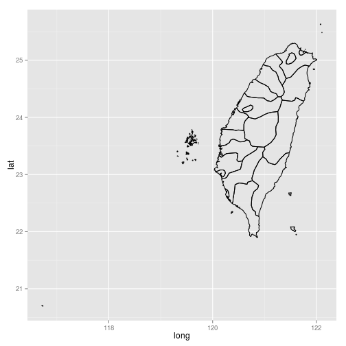

```r
### SpatialPolygonsDataFrame 객체를 직접 ggplot()에 전달하는 것도 가능하며,
### 이 경우 자동으로 fortify가 적용된다.
ggplot(taiwan_shp, aes(x=long, y=lat, group=group)) + geom_path()
```

————— the END —————–